[figure not shown]

# Android Fundamentals

## Unit 1: Get started

## 3.3 Support libraries

- Introduction
- What you'll learn
- What you'll do

#### Tasks

- Task 1: Set up your project to use support libraries
- Task 2: Implement the layout and MainActivity
- Task 3: Implement Button behavior

[Vocabulary words and concepts glossary](https://developers.google.com/android/for-all/vocab-words/)

1. Introduction

The Android SDK includes the Android Support Library, which is a collection of several libraries. These libraries provide features that aren't built into the Android framework, including the following:

- Backward-compatible versions of framework components, so that apps running on older versions of the Android platform can support features made available in newer versions of the platform
- Additional layout and user interface elements
- Support for different device form factors, such as TV devices or wearables
- Components to support Material Design elements
- Other features, including palette support, annotations, percentage-based layout dimensions, and preferences
1. What you'll learn
   - How to verify that the Android Support Library is available in your Android Studio installation.
   - How to indicate support library classes in your app.
   - How to tell the difference between the values for compileSdkVersion, targetSdkVersion, and minSdkVersion.
   - How to recognize deprecated or unavailable APIs in your code.
   - More about the Android support libraries.
1. What you'll do
   - Create a new app with one TextView and one Button.
   - Verify that the Android Support Repository (containing the Android Support Library) is available in your Android Studio installation.
   - Explore the build.gradle files for your app project.
   - Manage class or method calls that are unavailable for the version of Android your app supports.
   - Use a compatibility class from the support library to provide backward-compatibility for your app.

## App overview

In this practical you'll create an app called HelloCompat with one TextView that displays "Hello World" on the screen, and one Button that changes the color of the text. There are 20 possible colors, defined as resources in the color.xml file, and each button click randomly picks one of those colors.

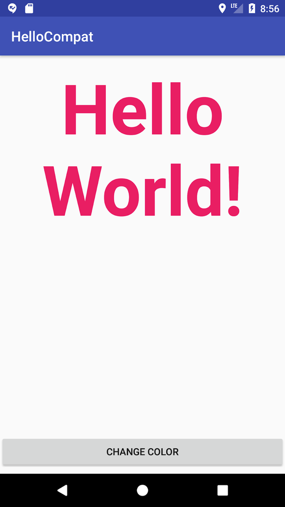

The methods to get a color value from the app's resources have changed with different versions for the Android framework. This example uses the `ContextCompat` class in the Android Support Library, which allows you to use a method that works for all versions.

## Task 1: Set up your project to use support libraries

#### 1.1 Verify that the Android Support Repository is available

#### 1.2 Set up the project and examine build.gradle

## Task 2: Implement the layout and MainActivity

#### 2.1 Change the layout and colors

#### 2.2 Add behavior to MainActivity

## Task 3: Implement Button behavior

#### 2.1 Add the changeButton() click handler

#### 2.2 Implement the Button action

## [HelloCompat - Solution Code](https://github.com/google-developer-training/android-fundamentals-apps-v2/tree/master/HelloCompat)

## Coding challenge

**Challenge:** Rather than using `ContextCompat` for to get the color resource, use a test of the values in the [Build](https://developer.android.com/reference/android/os/Build.html) class to perform a different operation if the app is running on a device that supports a version of Android older than API 23.